# Lab 19 - Non-Parametric Tests

Nick Sumpter (Edited by Eddie-Williams Owiredu & Guy Twa)

2024-11-4

# Today’s Lab

This lab will test your ability to determine when a non-parametric test is appropriate to use on data that does not meet all assumptions of a parametric test and to perform the appropriate analysis. We will use 3 of the most common non-parametric tests: the Wilcoxon Rank Sum (Mann-Whitney) Test, the Wilcoxon Signed Rank test, and the Kruskal-Wallis Rank Sum test. These are the non-parametric equivalents of the independent t-test, the dependent t-test, and the one-way independent ANOVA respectively.

# Loading Packages and Data

```r
library(car)
library(pastecs)
library(tidyverse)

theme_set(theme_bw())

setwd("~/Documents/class/GBSC731/Lab19")

load("Non-Parametric-Data.RData")

source("functions.R")
```

## Getting to Know Your Data

In this lab, we will be using data stored in the file `Non-Parametric-Data.Rdata` on Canvas. There are 3 different datasets: `ad.2vars`, `ad.3vars`, and `noise.g`. We will use these examples for the Wilcoxon Rank Sum (Mann-Whitney) test, the Kruskal-Wallis Rank Sum test, and the Wilcoxon Signed Rank test respectively. Though these datasets may not deviate from the assumptions of the equivalent parametric tests, you can still apply these tests (they will however have less power to detect an association than their parametric equivalents).

Both `ad` datasets have `drug.tx` and `mmse` variables denoting the drug treatment and the score on the test, with the `ad.2vars` and `ad.3vars` datasets containing two and three levels of drug treatment respectively. The `noise.g` dataset has `noise.level` and `score` variables denoting the noise level during the visual detection task and the score on the task (repeated measures).

We want to determine whether there’s an effect of drug treatment on mmse scores in our `ad.2vars` and `ad.3vars` datasets, while we want to see if the `noise.level` variable effects score in the `noise.g` dataset. Let’s try to visualize the mean value of the outcome variables at each combination of our grouping variables. Notice that all of our data is already in the long format, so no need to pivot this time.

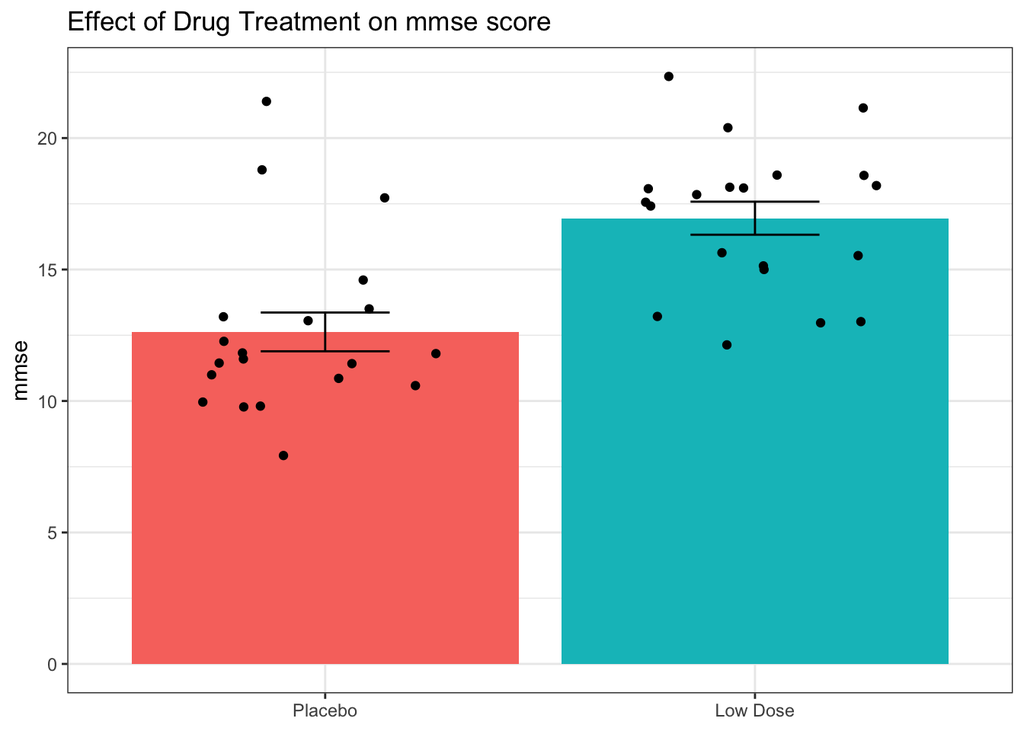

```r
ggplot(data = ad.2vars, mapping = aes(x = drug.tx, y = mmse)) +
  geom_bar(mapping = aes(fill = drug.tx), stat = "summary", fun = "mean", show.legend = FALSE) +
  geom_errorbar(stat = "summary", fun.data = "mean_se", width = 0.3) +
  geom_jitter(width = 0.3) +
  labs(title = "Effect of Drug Treatment on mmse score") +
  theme_bw() +
  theme(axis.title.x = element_blank())
```

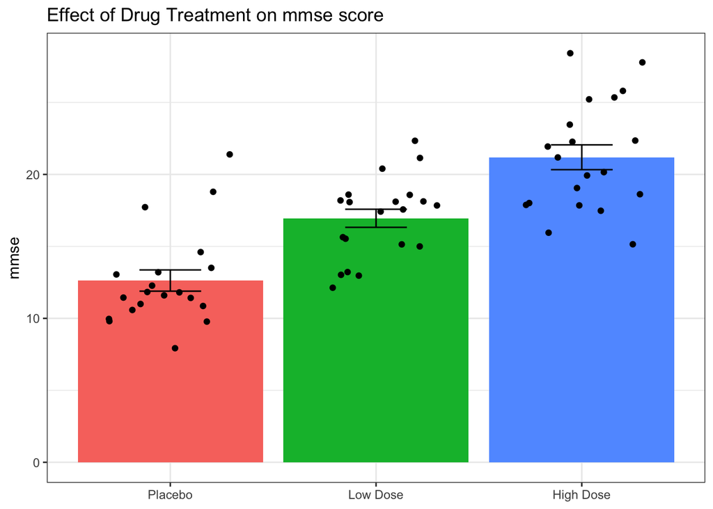

```r
ggplot(data = ad.3vars, mapping = aes(x = drug.tx, y = mmse)) +
  geom_bar(mapping = aes(fill = drug.tx), stat = "summary", fun = "mean", show.legend = FALSE) +
  geom_errorbar(stat = "summary", fun.data = "mean_se", width = 0.3) +
  geom_jitter(width = 0.3) +
  labs(title = "Effect of Drug Treatment on mmse score") +
  theme_bw() +
  theme(axis.title.x = element_blank())
```

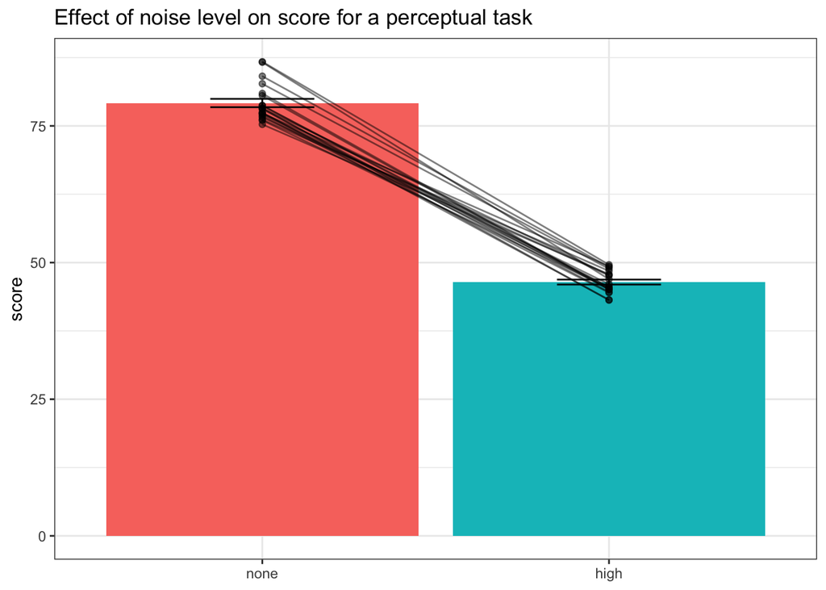

```r
ggplot(data = noise.g, mapping = aes(x = noise.level, y = score)) +
  geom_bar(mapping = aes(fill = noise.level), stat = "summary", fun = "mean", show.legend = FALSE) +
  geom_errorbar(stat = "summary", fun.data = "mean_se", width = 0.3) +
  geom_point(alpha = 0.5) +
  geom_line(mapping = aes(group = ID), alpha = 0.5) +
  labs(title = "Effect of noise level on score for a perceptual task") +
  theme_bw() +
  theme(axis.title.x = element_blank())
```

From just an eyeball test, it looks like the Placebo group had lower scores than the Low Dose group in the ad.2vars dataset, the High Dose group had an even higher score in the ad.3vars dataset, and the “none” noise level had a higher score than the “high” noise level in the noise.g dataset.

# Wilcoxon Rank Sum (Mann-Whitney) Test

The Mann-Whitney test is the non-parametric equivalent to the independent t-test. It is used to test the null hypothesis that the two samples likely derive from the same population (i.e. whether they have similar distributions). It can also be thought of as testing the difference in medians between groups.

## Assumptions of the Wilcoxon Rank Sum (Mann-Whitney)

Recall that an independent t-test has the following assumptions:

- Independence
- Normality of the variable within each group
- Homogeneity of variance across groups

The Mann-Whitney test only assumes independence. For our example, we know that independence is met, therefore our assumptions are met.

## Running the Test

The Mann-Whitney test is run using the `wilcox.test()` function. It takes the exact same inputs as the t.test function.

If you are using R version 4.3 or below, you can use the following formulation:

`wilcox.test(y ~ x, data = dataset, paired = FALSE)`

However, If you are using R version 4.4 or above, you do **not** need to specify `paired = FALSE`

```r
wilcox.test(mmse ~ drug.tx, data = ad.2vars)
```

```
##
##  Wilcoxon rank sum exact test
##
## data:  mmse by drug.tx
## W = 61, p-value = 7.938e-05
## alternative hypothesis: true location shift is not equal to 0
```

**Do the two samples appear to derive from different populations?**

Yes, based on the p-value less than 0.05, we can reject the null hypothesis that the two samples are from the same population and therefore state that there is a significant difference in mmse scores as a function of the drug treatment group.

# Wilcoxon Signed Rank Test

The Wilcoxon Signed Rank test is the non-parametric equivalent to a paired t-test. This can be thought of as testing the null hypothesis that the median difference between the groups is zero.

## Assumptions of the Wilcoxon Signed Rank Test

The major assumption for a dependent t-test is normality of the differences between groups. In the Wilcoxon Signed Rank Test, however we do not have this requirement.

## Running the Test

The Wilcoxon Signed Rank test is also performed using the function `wilcox.test()`, with the only difference from above being that paired is set to `TRUE`.

If you are using R version 4.3 or below, you can use the following formulation:  
`wilcox.test(score ~ noise.level, data = noise.g, paired = TRUE)`

However, If you are using R version 4.4 or above, you’ll need to supply your data in the following format:

```r
# The x and y arguments here, correspond to the vector of scores for each sound level
wilcox.test(x = noise.g %>%
              filter(noise.level == "none") %>%
              pull(score),
            y = noise.g %>%
              filter(noise.level == "high") %>%
              pull(score),
            paired = TRUE)
```

```
##
##  Wilcoxon signed rank exact test
##
## data:  noise.g %>% filter(noise.level == "none") %>% pull(score) and noise.g %>% filter(noise.level == "high") %>% pull(score)
## V = 210, p-value = 1.907e-06
## alternative hypothesis: true location shift is not equal to 0
```

**Can we reject the null hypothesis that the median difference between noise levels is 0?**

Yes! Based on the Wilcoxon Signed-Rank test, we can reject the null hypothesis and state that there is a significant difference in median score between noise levels.

# Kruskal-Wallis Rank Sum Test

Finally, the Kruskal-Wallis test is the non-parametric equivalent of the one-way independent ANOVA. It is essentially the Wilcoxon Rank Sum (Mann-Whitney) test but it is for situations with more than two levels in the grouping variable. One limiting factor about this test is that is cannot be used with repeated measures data, only independent data.

## Assumptions of the Kruskal-Wallis Rank Sum Test

The one-way independent ANOVA requires independence, normally distributed residuals in each group, and homogeneity of variance of residuals between groups. The Kruskal-Wallis test does require independence but not require the other assumptions.

## Running the Test

The Kruskal-Wallis test is performed using the `kruskal.test` function and has essentially the same setup as the `wilcox.test` function we have been using so far.

```r
kruskal.test(mmse ~ drug.tx, data = ad.3vars)
```

```
##
##  Kruskal-Wallis rank sum test
##
## data:  mmse by drug.tx
## Kruskal-Wallis chi-squared = 31.385, df = 2, p-value = 1.531e-07
```

As you can see, we have a significant main effect of drug treatment on mmse scores. Like with the basic ANOVA, this does not tell us which groups are different, just that a difference exists. We will need to run post-hoc tests to determine where the actual differences between groups are.

## Post-Hoc Analysis of a Kruskal-Wallis Test

Unfortunately, we can’t just use the pairwise.t.test function we used previously for post-hoc tests since that is for parametric data. Luckily, there is an analogue to this function for nonparametric data called pairwise.wilcox.test.

This function behaves exactly like pairwise.t.test, just pass in the data, the grouping variable, and the pairwise correction method.

`pairwise.wilcox.test(dataset$y, dataset$x, p.adjust.method = 'bonferroni')`

The output for the post-hoc test will look like the following:

```r
pairwise.wilcox.test(x = ad.3vars$mmse, g = ad.3vars$drug.tx, p.adjust.method = "bonferroni")
```

```
##
##  Pairwise comparisons using Wilcoxon rank sum exact test
##
## data:  ad.3vars$mmse and ad.3vars$drug.tx
##
##           Placebo Low Dose
## Low Dose  0.00024 -
## High Dose 1.5e-07 0.00224
##
## P value adjustment method: bonferroni
```

As you can see from the corrected p-values in the output table, all three pairwise tests were significant and thus there is a significant difference between all three pairs of groups. We could also use Holm correction if preferred.

# Independent Practice

Go ahead and run the nonparametric versions of t-tests on the data from lab 11 (T-test.RData). As a reminder this includes the sniff.ind and sniff.dep datasets.

1. Get to know your data and describe your variables (independent vs. dependent, categorical or continous)
2. Test your assumptions for the appropriate t-test or nonparametric version
3. Regardless of whether your t-test assumptions are met, run the appropriate nonparametric test and report your findings as you would describe them in a Results section

Now run the nonparametric version of the one-way independent ANOVA on the hp variable as a function of the cyl variable in the mtcars dataset.

1. Get to know your data and describe your variables (independent vs. dependent, categorical or continous)
2. Test your assumptions for the appropriate ANOVA or nonparametric version
3. Regardless of whether your ANOVA assumptions are met, run the appropriate nonparametric test and report your findings as you would describe them in a Results section